[figure not shown]

# Planning under uncertainty

AI-guided design of efficient clinical trials with BATON

Naim Rashid

Department of Biostatistics · Lineberger Comprehensive Cancer Center · UNC Chapel Hill

Computational Medicine Seminar · September 4, 2026

[figure not shown]

## Overview

Section 1

The problem

Complex adaptive design becomes a search problem.

Section 2

BATON

A search over a trial simulator.

Section 3

Does it work, and what did it change?

Section 1

The problem

Why isn’t simulation alone enough?

## A clinical trial is an experiment built for a decision

**The question**  
Does the treatment beat a benchmark or a control?

**How patients are used**  
Single-arm (everyone gets the treatment) or randomized (treatment versus control).

**Two errors**  
Advance a treatment that fails, or drop one that works.

Two choices dominate: how many patients, and which rule decides.

## Bayesian adaptive trials decide as they go. Each rule adds settings.

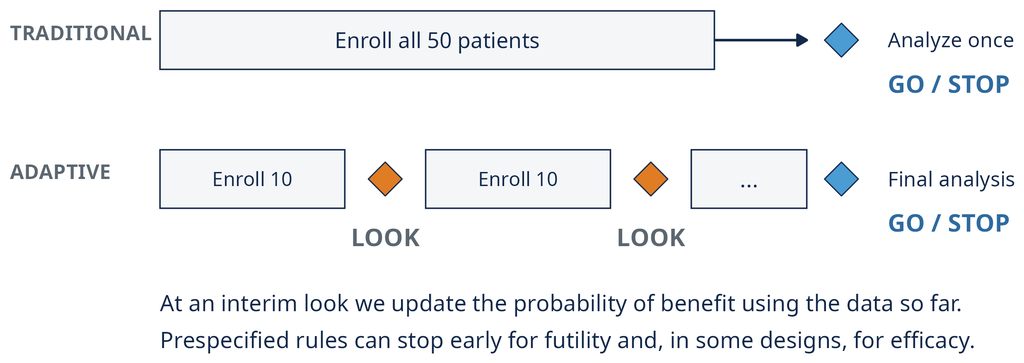

Maximum N, look timing, futility and efficacy thresholds, priors, margins: **8 to 13 interacting choices**, and every one changes how the trial behaves.

## Feasible designs meet prespecified error-rate and power targets

**Type I error (false go)**  
Share of simulated trials declaring efficacy under the null. Cap: **0.10**.

**Power (true go)**  
Share declaring efficacy when the treatment works as hypothesized. Floor: **0.80**.

|  | Typical trial | EVOLVE |
| --- | --- | --- |
| Designs needed | One | Many subtrials |
| Design parameters | Few | Many, interacting |
| Power and type I error | Often closed-form | Simulation only |

## Simulation tells us how one candidate behaves. It does not tell us which candidate to try next.

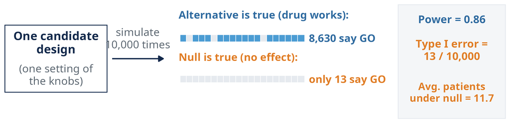

## EVOLVE: one master protocol, 10 to 15 cohorts opened over time, each needing its own design

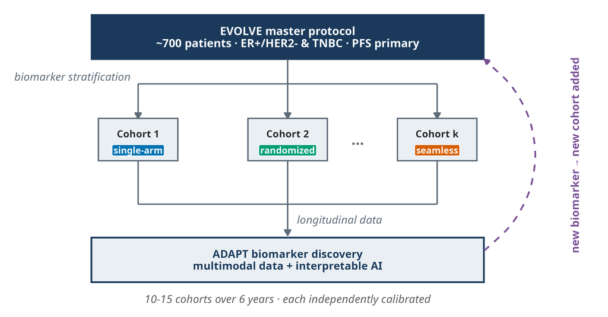

Not one calibration problem. Ten to fifteen of them, each with its own design, opened on a short clock.

## One subtrial became a two-week search

2 weeks

manual tuning of one subtrial’s design  
**8 interacting settings**

power stalled at 0.78 with 39.2 expected patients when the treatment is inactive

Several more subtrials were waiting. And even if you find a feasible design, is it efficient under the objective you actually care about?

## This is not just EVOLVE: simulation-calibration recurs across adaptive trial designs

**Phase I dose-finding**  
escalation and safety rules tuned by simulation

**Phase II Bayesian designs**  
posterior thresholds and interim looks tuned by simulation

**Platform trials**  
every added feature adds settings that interact

Same shape every time: many interacting settings, operating characteristics evaluated by simulation, and calibration that still requires search.

## Grid search scales poorly; random search wastes evaluations in our benchmark

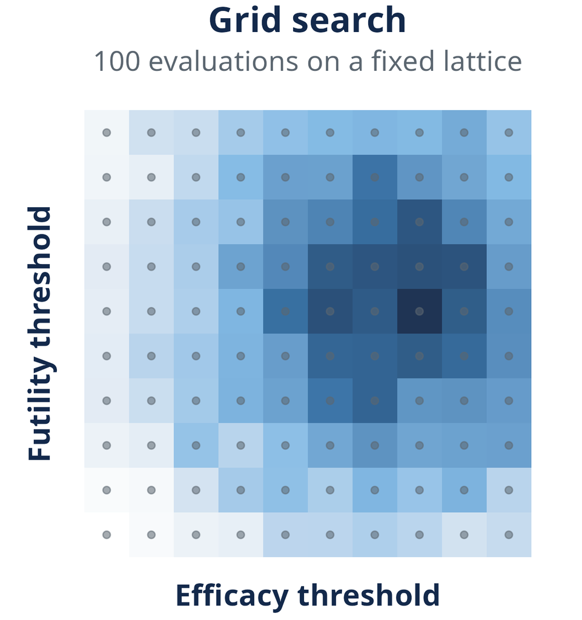

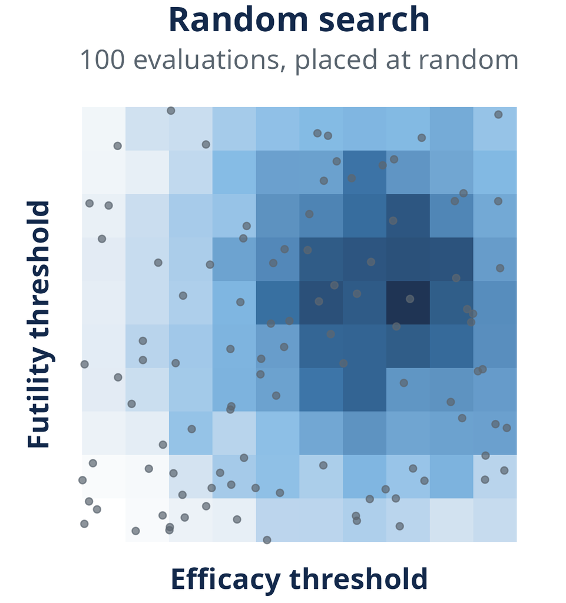

In two dimensions a grid is easy. As dimensions grow, the number of combinations explodes. Random search spent 93% of its 2,000 evaluations on designs that fail. (Darker = better design.)

Section 2

BATON

What should we simulate next?

## This is a familiar computational problem

**Machine learning**  
hyperparameters  
↓  
expensive training run  
↓  
validation performance

**Trial design**  
design parameters  
↓  
expensive Monte Carlo simulation  
↓  
power, type I error, enrollment

The same computational shape as hyperparameter tuning, except feasibility is defined by hard statistical constraints.

## BATON needs a simulator, not a formula

**BATON**: Bayesian Adaptive Trial OptimizatioN

**Constrained Bayesian optimization**: surrogates learn power, type I error, and enrollment; they choose the next candidate.

**You specify**: a power floor, a type I error cap, what to minimize.

**Your simulator**: settings and scenarios in, operating characteristics out.

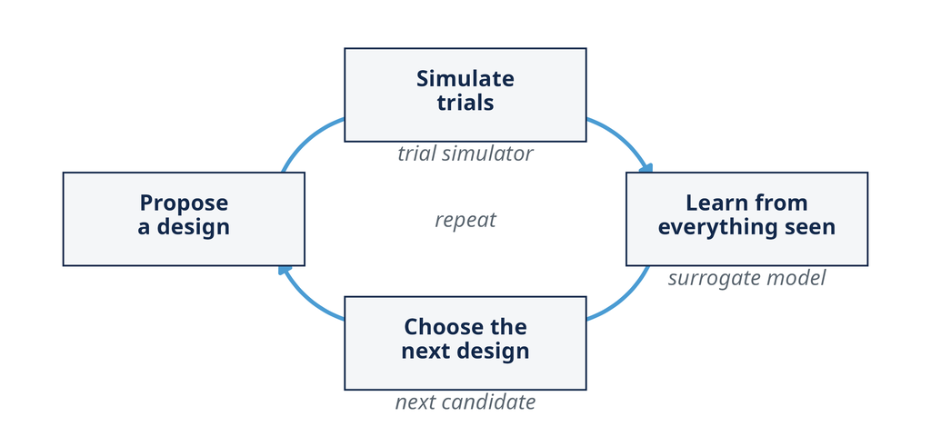

A closed loop: simulate, learn, choose, repeat.

## A surrogate predicts designs we have not paid to simulate

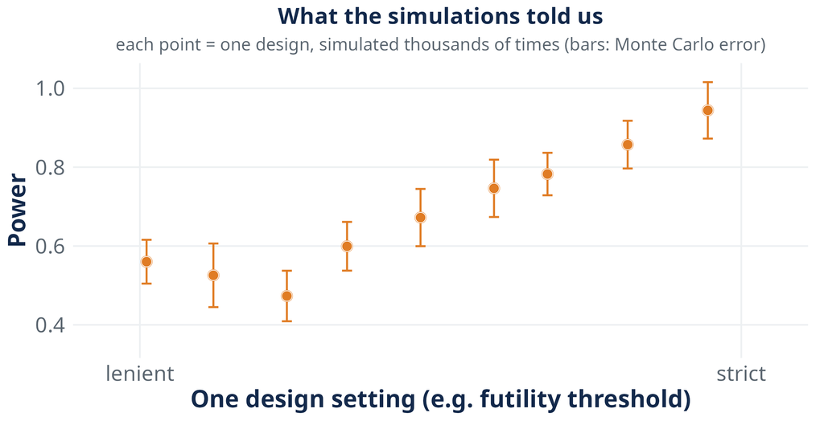

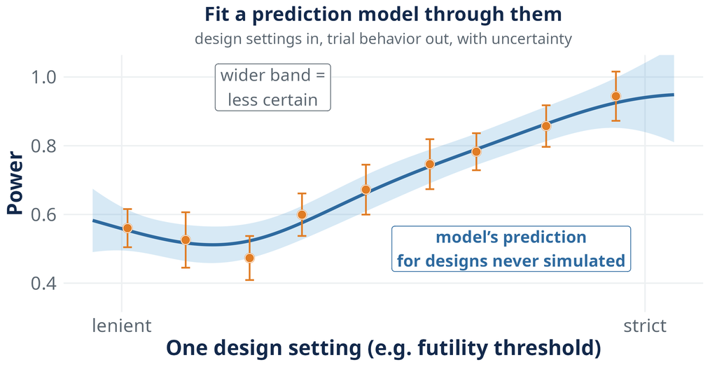

Design settings in, trial behavior out, and the model says how sure it is.

## The next simulation goes where it has the greatest expected value for improving the feasible design

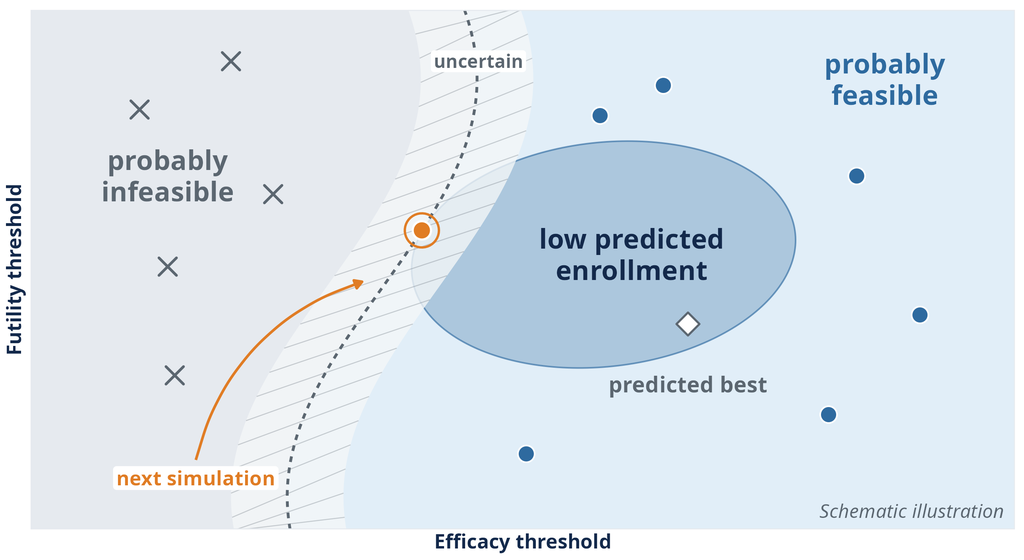

Balance the potential improvement in the objective against the probability that the design satisfies the constraints.

## The seed sketches the map. Then BATON proposes each batch.

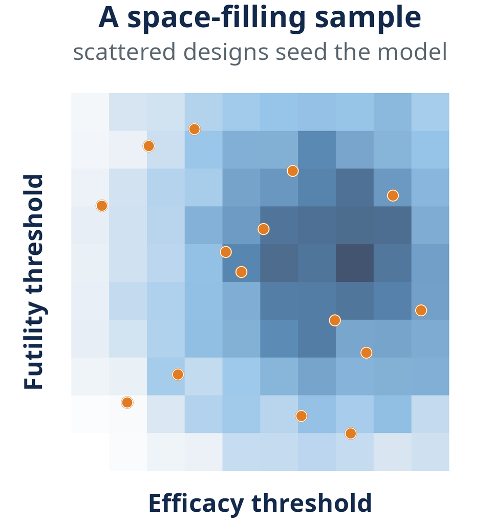

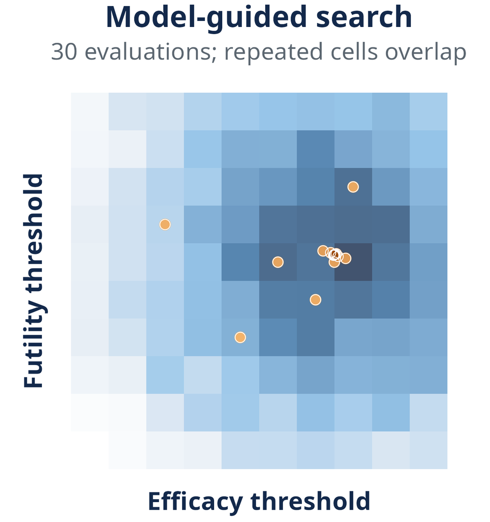

Initial points learn broadly; later points concentrate where the answer may improve.

## Spend precision where it matters

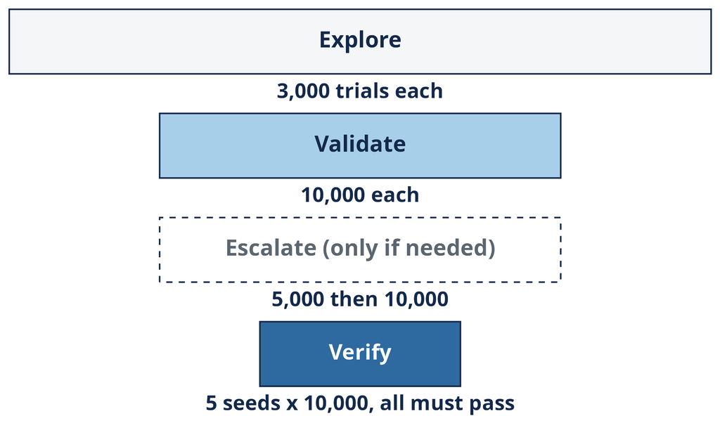

Cheap screening for the many, expensive re-checks for the few, multi-seed verification for the one design you report.

Section 3

The evidence

Feasibility, efficiency, and richer designs

## On a problem with a known answer, BATON recovers the optimum or a near-neighbor

Simon’s two-stage design: enroll n1, stop if too few responses, otherwise enroll to n. Every candidate in this design class can be enumerated, so the exact constrained optimum is known.

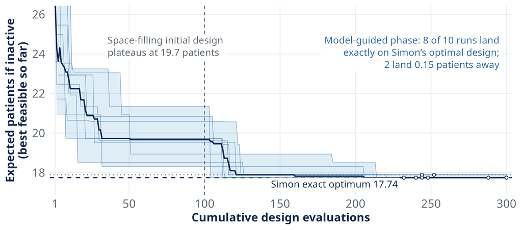

10 random starts: 8 return Simon’s exact optimal design; 2 land 0.15 patients away.

## Across 12 benchmarks: feasible in all 12, median objective gap 2.5%

One run per scenario; ratio = BATON’s expected null enrollment / Simon’s exact optimum.

[output not shown]

Feasibility is verified directly. Objective optimization remains approximate.

## In EVOLVE, BATON found a feasible design where manual tuning had stalled

**MANUAL**  
2 weeks  
power 0.78  
**39.2 expected patients if inactive**  
infeasible

**BATON**  
~4-hour workflow  
power 0.86  
**11.7 expected patients if inactive**  
feasible

Illustrative comparison, not a controlled benchmark across analysts. Same simulator, same constraints.

## Same requirements, different trials

Many designs meet power ≥ 0.80 and type I error ≤ 0.10. Which should we optimize for?

EVOLVE’s TNBC cohort, different objectives:

|  | Design A | Design B |
| --- | --- | --- |
| Maximum patients | **47** | **30** |
| Expected patients, inactive treatment | **11.7** | **22.8** |
| Power | 0.86 | 0.94 |
| Type I error | 0.001 | 0.021 |

One quits losers quickly; one caps the worst case. Neither is better.

## The objective should reflect the trial you want

#### H0-Optimal (quit losers quickly)

H0: no better than the benchmark

Minimize expected N under the null; larger maximum N.

#### Minimax (cap the worst case)

Minimize maximum N; more patients under the null.

#### Admissible (the compromise)

A weighted blend, explicit.

Two-stage designs made these tradeoffs explicit for decades; BATON does so at scale.

## EVOLVE’s TNBC cohort: three objectives, three designs

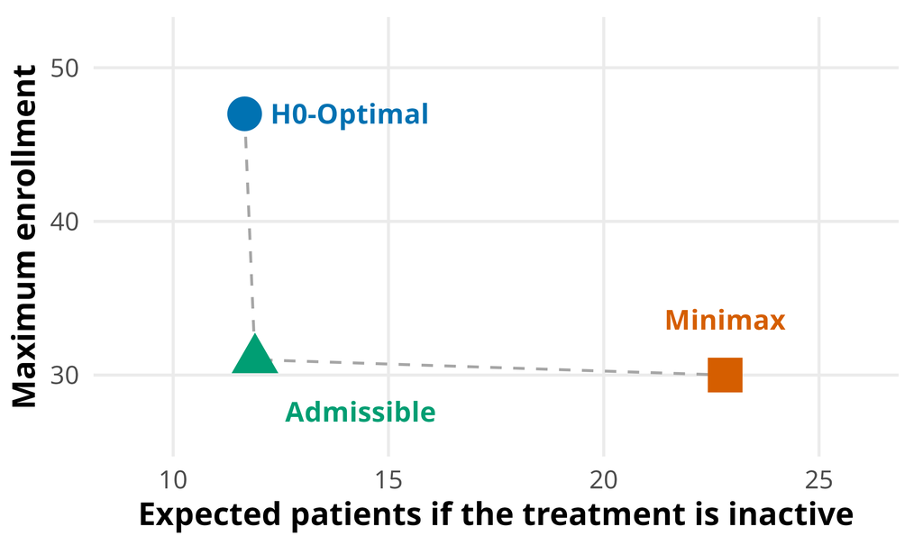

**The platform’s TNBC cohort**

- H0-Optimal: 47 max, **11.7** if the treatment is inactive
- Admissible: 31 max, **11.9**
- Minimax: 30 max, **22.8**

For one additional patient of maximum capacity, Admissible saves about eleven patients on average when the treatment is inactive. That made the compromise especially attractive.

## Search makes a 13-parameter seamless design practical to calibrate

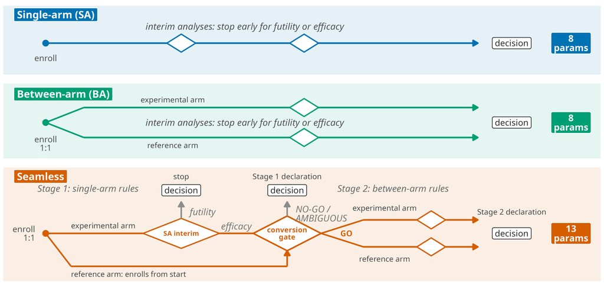

Screen first with a single-arm stage, then demand randomized evidence from the cohorts that earn it. Thirteen interacting parameters, calibrated by automated search.

## Two philosophies converged on the same 13-parameter design

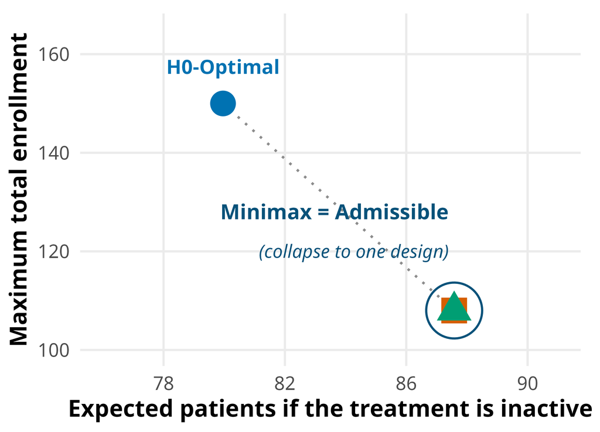

Minimax and Admissible calibrated to the identical design. That is not a coincidence, and the next slide shows why.

## The gate rarely opens when the treatment is inactive, so the two objectives collapse

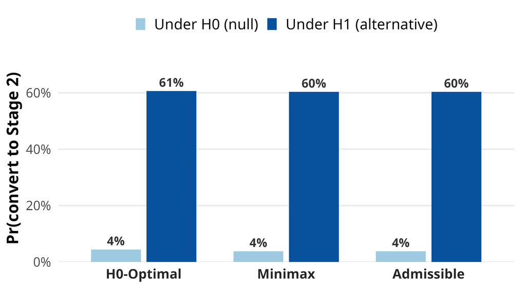

When the treatment is inactive, only ~4% of trials reach stage 2. Expected enrollment therefore changes very little with stage-2 size, so the maximum-enrollment component drives the Admissible solution toward Minimax. H0-Optimal can tolerate a larger stage 2 because its objective never penalizes maximum N.

## BATON informed EVOLVE’s operational decisions

**Capacity**: maximum N locked 3 months before first enrollment, from the frontier.

**Program planning**: enrollment and timeline projections for 10 to 15 subtrials.

**Interim calendar**: look spacing set the safety board’s schedule.

**Turnaround**: a feasible design in under 45 minutes; workflow about 4 hours.

We generally chose Admissible designs: efficient enrollment, early stopping, bounded capacity.

## BATON is designed as a general framework, not an EVOLVE-specific tool

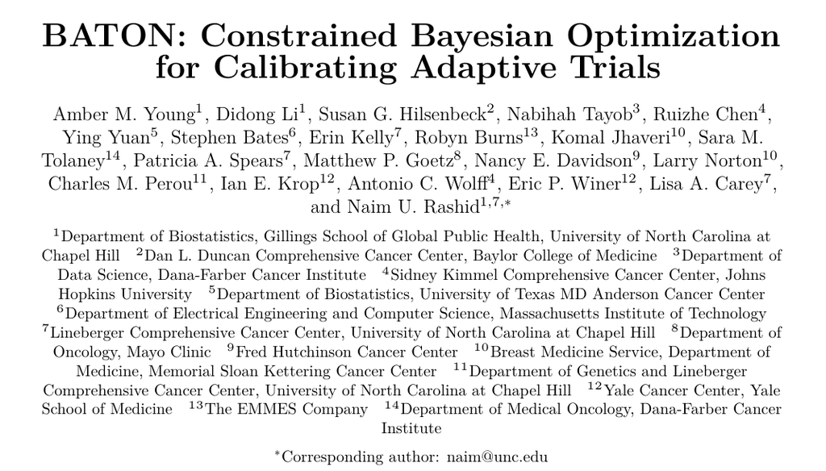

[figure not shown]

**Manuscript under review at JASA**  
**Open-source R package**  
**Bring your own trial simulator**

## Problems often emerge late

54%  
of 640 therapeutics reaching phase 3 or pivotal trials **failed in late-stage development**; 57% of failures for inadequate efficacy

Locally reasonable decisions can leave problems that only become visible downstream.

Hwang et al., JAMA Internal Medicine 2016

## Early decisions become downstream commitments

**Sotorasib (KRAS G12C)**  
**960 mg**: highest phase I dose tested  
↓ carried forward  
selected, developed, approved  
↓ after approval  
FDA required a **240 vs 960 mg** comparison  
↓  
**median PFS was similar at 240 mg and 960 mg**

The optimal-dose question remained unresolved until after approval.

Source: CodeBreaK 100 dose comparison; Ann Oncol 2023, Eur J Cancer 2024

## We optimize the trial. The program is what succeeds.

**Phase I**  
choose dose

choice carries forward  
→

**Phase II**  
choose population, signal

uncertainty carries forward  
→

**Confirmatory trial**  
must resolve remaining uncertainty

**What if we reverse the logic?**  
**final therapeutic claim** + its evidentiary requirements  
↓  
simulate alternative development architectures  
↓  
phased · seamless · **potentially phaseless**

Phase structure becomes a design variable.

## Extending the same search logic across development

#### Across possible futures

BATON-C · in progress, with Amber Young

Optimize over a *prespecified family* of plausible truths, not one.

#### Earlier in development

BATON-D · in progress

Optimize dose-finding rules for safety *and* for what later trials inherit.

#### Across trials

Phaseless / whole-program design · long-term goal

Optimize dose, population, interim, and confirmatory decisions as *one program*.

## What I hope you remember

1. For complex adaptive trials, simulation tells us how a candidate behaves; design is the search for what to try next.
2. BATON searches the simulator for feasible, efficient designs and makes the patient-use tradeoffs explicit.
3. Tractable calibration lets us consider richer adaptive trials; the same search logic extends to other decisions across development.

## Acknowledgments

#### EVOLVE / ADAPT

- MPIs: Lisa Carey (UNC), Ian Krop (Yale), Chuck Perou (UNC), Eric Winer (Yale), Antonio Wolff (Hopkins)
- EVOLVE steering committee and site investigators across 15 TBCRC sites
- ARPA-H ADAPT program leadership

#### Statistics / BATON

- **Amber Young** (UNC), who led BATON's design and validation, and co-leads BATON-C
- **Didong Li** (UNC) · **Dinelka Nanayakkara** (ARPA-H statistics group)
- Statistical working group: Ruizhe Chen (Hopkins), Sue Hilsenbeck (Baylor), Nabihah Tayob (DFCI)
- Rashid Lab

FUNDING · ARPA-H 140D042590009 · NCI P50-CA257911 (UNC SToP SPORE) · DOD HT9425241103100121 · NCI U01-CA274298

Thank you

Questions

naim@unc.edu · rashidlab.github.io  
BATON R package: github.com/naimurashid/BATON · manuscript under review at JASA

Backup

Reference slides

## Backup: the surrogate and the acquisition

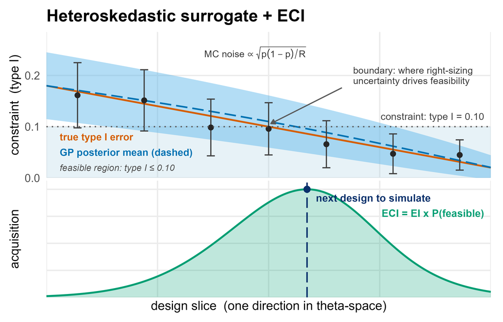

- One GP surrogate per behavior metric (power, type I, expected enrollments).
- **Heteroskedastic** noise model: Monte Carlo variance differs across the space (early-stopping designs give noisier estimates per replication), and hetGP models it rather than assuming it constant.
- Acquisition: **expected constrained improvement**, expected objective gain multiplied by the modeled probability that *every* constraint is satisfied.
- Batched proposals; constraint estimates carry their Monte Carlo standard errors into the model.

## Backup: the 12-benchmark scatter

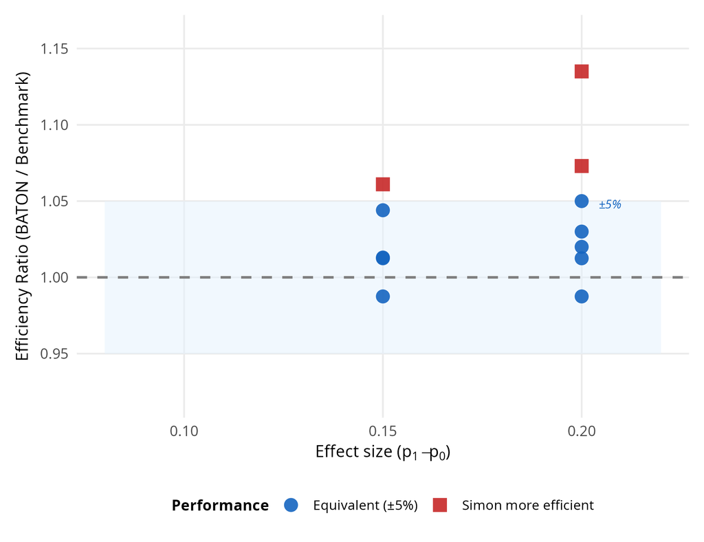

Always feasible: **12 of 12**. Exact optimum in **4 of 12**; median within **2.5%**; worst case **13.5%**.

Primary target: verified feasibility. Objective optimization is approximate in an expensive, noisy, discrete space.

## Backup: what the constraints and parameters actually are

**Calibrated (searched) parameters, single-arm:**

- maximum enrollment; interim spacing; minimum-events gate before decisions count
- posterior futility threshold; posterior efficacy threshold
- decision margin over the historical benchmark
- analysis-prior concentration; hazard-model resolution (piecewise intervals)

Seamless adds conversion-gate thresholds and second-stage sample-size and stopping parameters (13 total).

**Constraints (headline scenarios):**

- type I error at most the ceiling (0.10 in the scenarios shown)
- power at least the floor (0.80)
- seamless designs add gate-behavior constraints (null conversion rate bounded, alternative conversion rate floored)

**Objectives, by philosophy:** expected null enrollment (H0-Optimal), maximum enrollment (Minimax), weighted blends (Admissible family), expected alternative enrollment (H1-Optimal).

Scenario A truths: null median 3.8 months, alternative 9 (hazard ratio 0.42), Weibull shape 1.3, accrual 2 per month; maximum enrollment searched in [30, 120]. Two Simon scenarios use a 0.05 ceiling with 0.90 power.

## Backup: related work and what BATON adds

**Existing approaches**

- **BOP2 / GBOP2** (Zhou; Zhao): grid or particle-swarm search over posterior-probability stopping thresholds; return one design under one criterion.
- **Operating-characteristic acceleration** (Golchi 2022): speeds the estimation, does not optimize the design.
- **Single-objective BO for trial design** (Richter 2022): one objective, without multi-constraint feasibility.
- **gsDesign / rpact / BATSS**: group-sequential and frequentist tooling.

**What BATON adds, jointly in one framework**

1. finds **feasible** designs under **multiple noisy** behavior constraints;
2. models **heteroskedastic** Monte Carlo error;
3. optimizes under **philosophy-specific** sample-size objectives.

It exposes the trade-off surface, and reveals **when philosophies coincide and why**.

## Backup: known failure modes and limits

- **Budget exhaustion**: 3 of 10 reproducibility runs used the full 300-evaluation budget rather than stopping early; quote evaluations used, not “convergence.”
- **Approximate optimization**: worst benchmark gap 13.5% from the enumerated optimum (single seed); the guarantee is high-fidelity feasibility, not exact optimality.
- **Correlated constraints**: the acquisition multiplies marginal feasibility probabilities; latent surfaces for power and type I error can be correlated. Affects the search only; reported designs are verified directly.
- **No common random numbers in the loop**: candidate comparisons carry full independent Monte Carlo noise; verification uses a shared seed set.
- **One assumed truth per calibration**: every current result conditions on an assumed clinical scenario; robustness across scenarios is BATON-C, in progress.

## Backup: bidirectional stopping variants

The single-arm and between-arm headline scenarios use futility-only interim stopping (interims can stop for futility; efficacy is decided at the end). The seamless design is calibrated with bidirectional stopping throughout, because its conversion gate is efficacy-driven. The paper’s supplement repeats the single-arm and between-arm calibrations with **bidirectional** stopping, where interims may also stop early for efficacy.

- The frontier structure persists, but the philosophies compress: under bidirectional stopping in Scenario A, H0-Optimal and Admissible calibrate to the same maximum enrollment (31), separating only in thresholds.
- Expected enrollment under the alternative drops substantially (early efficacy stopping pays off exactly when the drug works).
- The choice between stopping structures is itself a design decision upstream of the philosophy choice.

## Backup: ten seeds, one design

The whole pipeline, rerun end to end at ten independent random seeds:

| Runs returning a feasible design | **10 / 10** |
| --- | --- |
| Runs returning Simon’s exact optimal design | **8 / 10** |
| Expected null enrollment, mean (spread) | **17.77** (0.06) |
| Evaluations used, median | 250 of a 300 budget |

The other two seeds return a near-neighbor design (capacity 29 instead of 25) whose expected enrollment differs by 0.15 patients. What reproduces is the design’s behavior, and usually the design itself.

For a method meant to sit inside regulatory submissions, this is not a nicety. That is the bar for a design going into a regulatory submission.

## Backup: the randomized-cohort frontier

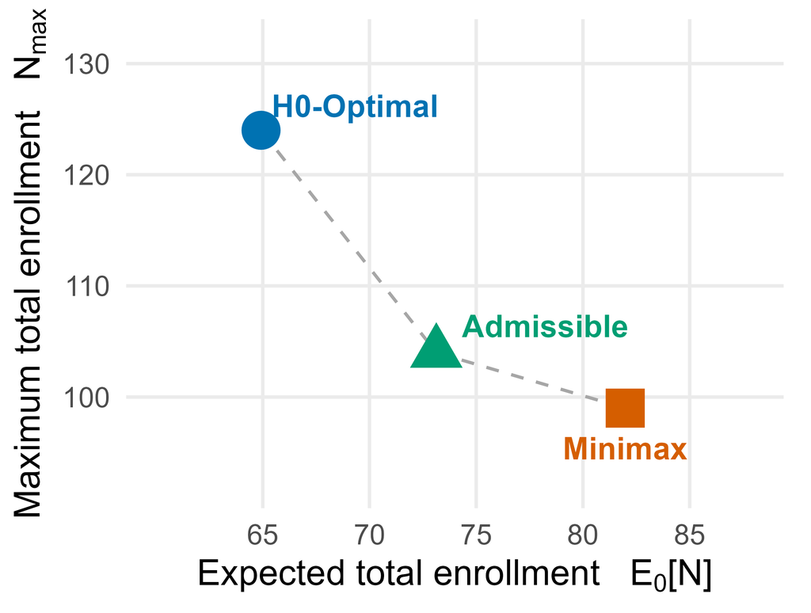

Cutting the worst-case cap from 124 to 104 costs about 8 extra patients on average when the treatment does not help; the next 5 cost about 9 more.

## Backup: the ARPA-H ask and the N-of-1 addition

*(ii) Clinical trial characteristics:*

1. Clinical trial for metastatic cancer patients.
2. Clinical trial that includes multiple lines of therapy under a single protocol.
3. Flexible clinical trial protocol that enables changes in design (e.g., randomized, adaptive, etc.).
4. Strong capability to collect tumor and blood-based measurements.
5. Possess a treatment line with a Progression Free Survival (PFS) rate of <9 months average.
6. Mechanisms for biomarker evaluation.
7. Modular clinical trial design enabling rapid dissemination and protocol uptake by different sites.

*(iii) General characteristics:* key clinical needs; evolutionary design examples and rapid-enrollment plans; treatment lines; biomarker testing and integration plans.

**New ask** (program-manager email): integrate an "N-of-1" trial component.

excerpts from the ARPA-H solicitation and program-manager correspondence

The ask: design an adaptive multi-line trial to discover, evaluate, and implement novel biomarkers, with an additional N-of-1 subcomponent

[figure not shown]

## Backup: ADAPT technical areas and the EVOLVE team

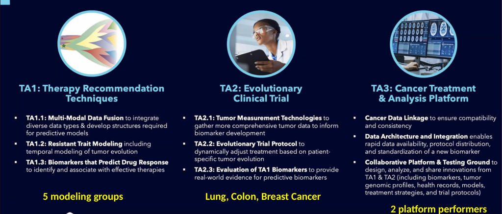

[figure not shown]